# Lab #11 - Symonds

April 8, 2026

In this lab, we’ll use data on traffic fatalities from [the National Highway Traffic Safety Administration (NHTSA)](https://cdan.dot.gov/) and from the World Health Organization.

**Install the required libraries:**

- `install.packages(c('dplyr', 'tidyr', 'ggplot2', 'gapminder'))`

```r
library(dplyr, warn.conflicts = FALSE)
library(tidyr)
library(ggplot2)
options(stringsAsFactors = FALSE)

MONTHS = c('January', 'February', 'March', 'April', 'May', 'June', 'July', 'August', 'September', 'October', 'November', 'December')
```

## About the Pedestrian Data

`sidewalks` - This column indicates whether sidewalks were present where the accident occurred.

- `na` indicates that sidewalk status wasn’t filled out that year (this item was only recorded starting in 2014)
- `none` indicates that *sidewalks were not noted* (we’ll assume this means there was no sidewalk)
- `yes` indicates sidewalks were present
- `unknown` indicates that it is not known if sidewalks were present

`speeding` - This column indicates whether the vehicle(s) involved were speeding.

```r
df.ped <- read.csv('http://files.ntsg.umt.edu/data/GIS_Programming/data/NHTSA_FIRST_pedestrians_in_fatal_crashes.csv', skip = 1) %>%
  pivot_longer(!(year:month), names_to = c('sidewalks', 'speeding'), values_to = 'count', names_sep = '_') %>%
  filter(month != 'Total') %>%
  mutate(month = ordered(month, levels = MONTHS))
head(df.ped)
```

```
## # A tibble: 6 × 5
##    year month   sidewalks speeding count
##   <int> <ord>   <chr>     <chr>    <int>
## 1  2007 January na        yes         46
## 2  2007 January na        no         401
## 3  2007 January none      yes          0
## 4  2007 January none      no           0
## 5  2007 January yes       yes          0
## 6  2007 January yes       no           0
```

## About the Pedalcyclist Data

Traffic wonks sometimes refer to cyclists as “pedalcyclists.”

```r
df.bike <- read.csv('http://files.ntsg.umt.edu/data/GIS_Programming/data/NHTSA_FIRST_pedalcyclists_in_fatal_crashes.csv', skip = 1) %>%
  pivot_longer(!(year:month), names_to = c('bike.location', 'road.type'), values_to = 'count', names_sep = '_') %>%
  filter(month != 'Total') %>%
  mutate(month = ordered(month, levels = MONTHS))
head(df.bike)
```

```
## # A tibble: 6 × 5
##    year month   bike.location      road.type  count
##   <int> <ord>   <chr>              <chr>      <int>
## 1  2007 January na                 interstate     0
## 2  2007 January travel.lane        interstate     0
## 3  2007 January bike.lane          interstate     0
## 4  2007 January sidewalk.crosswalk interstate     0
## 5  2007 January unknown            interstate     0
## 6  2007 January na                 freeway        1
```

## About the Global Data on Traffic Fatalities

These data were downloaded directly from [the World Health Organization’s website.](https://www.who.int/data/gho/data/indicators/indicator-details/GHO/estimated-road-traffic-death-rate-(per-100-000-population) They describe the estimate number of traffic fatalities (including motorists, pedestrians, and cyclists) per 100,000 people.

```r
df.global <- read.csv('http://files.ntsg.umt.edu/data/GIS_Programming/data/WHO_traffic_fatalities_by_year.csv') %>%
  select(Indicator, Region = ParentLocation, Location, Year = Period, Deaths.Per.100k = FactValueNumeric)
head(df.global)
```

```
##                                                    Indicator
## 1 Estimated road traffic death rate (per 100 000 population)
## 2 Estimated road traffic death rate (per 100 000 population)
## 3 Estimated road traffic death rate (per 100 000 population)
## 4 Estimated road traffic death rate (per 100 000 population)
## 5 Estimated road traffic death rate (per 100 000 population)
## 6 Estimated road traffic death rate (per 100 000 population)
##                  Region                         Location Year Deaths.Per.100k
## 1              Americas              Antigua and Barbuda 2019            0.00
## 2       Western Pacific Micronesia (Federated States of) 2019            0.16
## 3       South-East Asia                         Maldives 2019            1.63
## 4       Western Pacific                         Kiribati 2019            1.92
## 5 Eastern Mediterranean                            Egypt 2019           10.10
## 6                Europe                          Ukraine 2019           10.20
```

## Problem 11.1 - Reshaping Tables

Write a pipeline that reshapes `df.ped` so that is shows the count of pedestrians killed in motor vehicle accidents, **where sidewalks are *not* present and *regardless* of whether speeding was a factor,** with years **2014 and later** along the rows and months along the columns; i.e., the table should look something like this:

```
        January    February    March ...
2014
2015
2016
...
```

### Solution 11.1

```r
df.ped %>%
  filter(sidewalks == 'none', year >= 2014) %>%
  group_by(year, month) %>%
  summarize(count = sum(count), .groups = 'drop') %>%
  pivot_wider(names_from = month, values_from = count)
```

```
## # A tibble: 8 × 13
##    year January February March April   May  June  July August September October
##   <int>   <int>    <int> <int> <int> <int> <int> <int>  <int>     <int>   <int>
## 1  2014     250      251   239   236   226   245   264    276       271     313
## 2  2015     354      263   284   248   237   270   280    294       348     396
## 3  2016     330      309   309   284   307   275   293    356       352     487
## 4  2017     352      274   313   260   255   248   303    336       340     422
## 5  2018     362      322   322   262   328   296   291    355       387     432
## 6  2019     379      332   322   291   299   289   342    335       372     423
## 7  2020     402      383   339   241   303   327   399    384       445     491
## 8  2021     440      360   378   423   364   404   411    475       452     578
## # ℹ 2 more variables: November <int>, December <int>
```

## Problem 11.2 - Cyclist Fatalities by Year and Location

Create a bar/column plot showing the number of cyclist fatalities in each year *for each location where the cyclist was killed.* A stacked bar/column plot is recommended, but you can also use dodged bars or multiple plots, if you prefer, **provided that you write a single `dplyr` pipeline and use a single `ggplot()` function.**

Note that while `bike.location` was not reported until 2014, you should show all years of the data.

### Solution 11.2

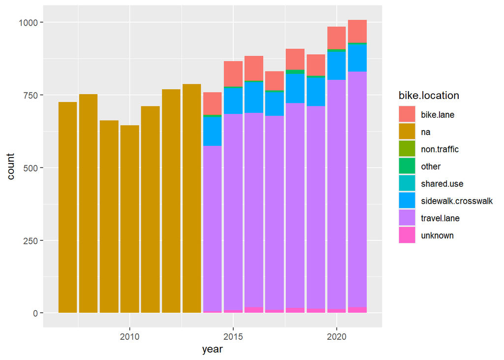

```r
df.bike %>%
  group_by(year, bike.location) %>%
  summarize(count = sum(count), .groups = 'drop') %>%
  ggplot(aes(x = year, y = count, fill = bike.location)) +
  geom_col()
```

## Problem 11.3 - Fatalities by Year

Using a single `ggplot()`, create a line plot showing Pedestrian and Pedalcyclist fatalities in each year.

- You should use faceting to create separate plots for Pedestrian and Pedalcyclist fatalities.
- You will probably need to *join* one data frame to another to achieve this.

**Hint:** Faceting is easier if your data frame is longer than it is wide; i.e., if there is a column that distinguishes between the groups of data you want to show in each facet. You may need to reshape the data frame, after joining.

### Solution 11.3

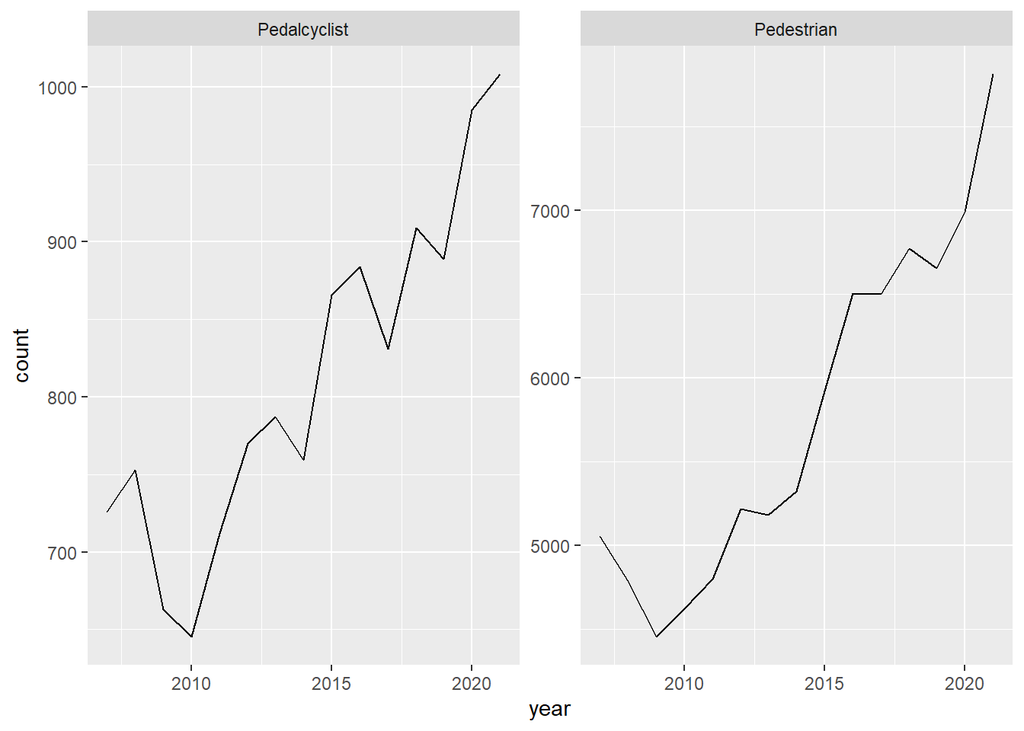

```r
full_join(
  df.ped %>%
    group_by(year) %>%
    summarize(Pedestrian = sum(count), .groups = 'drop'),
  df.bike %>%
    group_by(year) %>%
    summarize(Pedalcyclist = sum(count), .groups = 'drop'),
  by = 'year'
) %>%
  pivot_longer(-year, names_to = 'type', values_to = 'count') %>%
  ggplot(aes(x = year, y = count)) +
  geom_line() +
  facet_wrap(~type, scales = 'free_y')
```

## Interlude

```
## `summarise()` has regrouped the output.
## ℹ Summaries were computed grouped by Year and Region.
## ℹ Output is grouped by Year.
## ℹ Use `summarise(.groups = "drop_last")` to silence this message.
## ℹ Use `summarise(.by = c(Year, Region))` for per-operation grouping
##   (`?dplyr::dplyr_by`) instead.
```

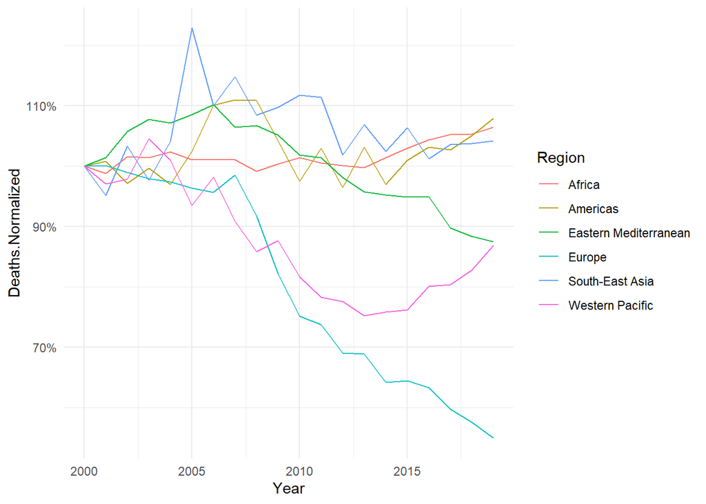

```r
df.global %>%
  group_by(Location) %>%
  arrange(Location, Year) %>%
  mutate(Deaths.Normalized = Deaths.Per.100k / Deaths.Per.100k[1]) %>%
  group_by(Year, Region) %>%
  summarize(Deaths.Normalized = mean(Deaths.Normalized)) %>%
ggplot(aes(x = Year, y = Deaths.Normalized)) +
  geom_line(aes(color = Region)) +
  scale_y_continuous(labels = scales::percent) +
  theme_minimal()
```

## Problem 11.4 - Global Traffic Fatalities

The “gapminder” dataset (loaded below) includes country-level data every 5 years up to 2007 on:

- Life expectancy: `lifeExp`
- Population: `pop`
- Per-capita gross domestic product (GDP): `gdpPercap`

```r
library('gapminder')
df.gapminder <- gapminder %>%
  mutate(country = as.character(country),
    continent = as.character(continent)) %>%
  mutate(country = if_else(country == 'United States', 'United States of America', country))
head(df.gapminder)
```

```
## # A tibble: 6 × 6
##   country     continent  year lifeExp      pop gdpPercap
##   <chr>       <chr>     <int>   <dbl>    <int>     <dbl>
## 1 Afghanistan Asia       1952    28.8  8425333      779.
## 2 Afghanistan Asia       1957    30.3  9240934      821.
## 3 Afghanistan Asia       1962    32.0 10267083      853.
## 4 Afghanistan Asia       1967    34.0 11537966      836.
## 5 Afghanistan Asia       1972    36.1 13079460      740.
## 6 Afghanistan Asia       1977    38.4 14880372      786.
```

**Is there a relationship between per-capita GDP and traffic fatalities? Create a scatterplot that answers this question.**

- Use `df.global` (the WHO dataset) and `df.gapminder`. Do not use `gapminder`.
- Use only data from 2007 (latest year of overlap between the two datasets)
- Color the points of the scatterplot according to the `continent`
- Use a base-10 logarithmic scale for the x-axis: `scale_x_log()`
- **Add a black dot showing where the United States (U.S.) falls on this plot.** Note that the U.S. is called `"United States of America"` in both datasets.

### Solution 11.4

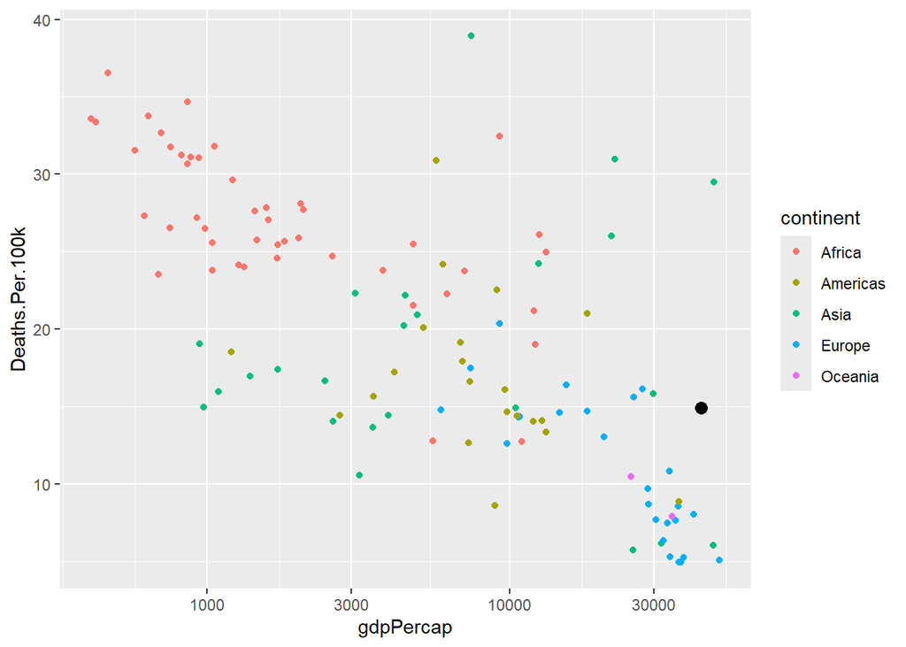

```r
df.2007 <- df.global %>%
  filter(Year == 2007) %>%
  inner_join(df.gapminder %>% filter(year == 2007), by = c('Location' = 'country'))

ggplot(df.2007, aes(x = gdpPercap, y = Deaths.Per.100k, color = continent)) +
  geom_point() +
  geom_point(data = filter(df.2007, Location == 'United States of America'),
    color = 'black', size = 3) +
  scale_x_log10()
```

The scatterplot suggests a significant negative relationship between per-capita GDP and traffic fatalities, where traffic fatalities tend to decrease as GDP per capita gets higher.